# Backtesting Improved Cross Exchange Arb (day-level granularity)

See $\texttt{simple}\_\texttt{backtest.ipynb}$ for a description of the prior iteration of this code.

## Introduction

The process/flow the data goes through is roughly the same as before, the trading logic is what has greatly improved.

**Improvements Made:**

**Data Flow:**

**Trading Logic:**

1. Determine the following for each exchange pair (e.g. Kraken - Bitfinex) $$ \gamma_{ij} = \frac{\text{Spread}^t_{ij} - \text{Spread}^{\mu}_{ij}}{\sigma^\mu_{ij}} $$ where $t$ is the current time, $\mu$ is the rolling window value, $\gamma$ is the number of standard deviations the move in price is, and $ij$ is exhcange $i$ - exchange $j$.
2. Compute $$ \{ \gamma_{ij}^* \} = \{\gamma_{ij} \space | \space \gamma_{ij} > \sigma_{\text{thresh}} \} $$ and the resulting $\{i^*, j^*\} $ ordered pairs. As a reminder these indices correspond to exchanges and $\sigma_{\text{thresh}}$ is a cutofff value in the range [1.5, 2.5].
3. To minimize trading costs we want to choose the $n$ highest $\gamma_{ij}^*$'s and trade *only* these pairs. If there is overlap (e.g. there is signal to trade Kraken-Bitstamp and Kraken-Gemini) we will allocate funds based on the strength of $\gamma_{ij}^*$. $$ \text{%_of_Funds}_{ij}^* = \frac{\gamma_{ij}^*}{\sum\limits_{{k \in \{j^*\}}} \gamma_{ik}^*} $$ where $\text{%_of_Funds}_{ij}^*$ is the percent of funds in account $i^*$ allocated to the $i^*, j^*$ trade. $\{j^*\}$ is the set of all $j^*$ paired with some $i^*$. $n$ will most likely be in the range [1, 3]. Also note that because we never want to be exposed to the underlying movements we restrict $\text{%_of_Funds}_{ij}^* = \text{%_of_Funds}_{ji}^*$. This means that if one account does not have enough funds in it we abondon the $\text{%_of_Funds}_{ij}^*$ approach and simply apply whatever possible to one side of the trade and then the rest to the other side drawing on that account (see example below).
4. Short currency in $i^*$ exchange and long in $j^*$ exchange in the amount: $(1-c) \times \text{Funds}_{ij}^* \times \text{%_of_Funds}_{ij}^* $.
5. For all currently held positions determine if $\gamma_{ij}^* \leq \sigma_\text{thresh} $ and if so, liquidate positions. If this frees up capital to move into an existing trade in one of those accounts, apply those funds. For example, if both a Kraken-Gemini and Kraken-Bitfinex trade were open and each had 30 and 70 percent of the Kraken funds respectively. You then determine that the Kraken-Gemini trade is within the threshold. You liquidate that position and apply the proceedds to *both* the other Kraken position but also the Bitfinex position. This needs to happen so that we remain unexposed to the underlying.

**Example:**

1. Short Account 2 in net amount: \$800(1-c) = \$368(1-c) + \$432(1-c)
   - Short Account 2 in amount: \$800(1-c) x 0.54 = \$432(1-c)
   - Short Account 2 in amount: \$800(1-c) x 0.46 = \$368(1-c)
2. Long Account 1 in amount: \$368(1-c)
3. Short Account 3 in net amount: \$68 = \$500(1-c) - \$432(1-c)
   - Long account 3 in amount: \$432(1-c)
   - Short account 3 in amount: \$500(1-c) _This would normally be \$518(1-c) to use the rest of the third accounts value (it is the short position so it takes precedence), but account 4 only has \$500 in it so we cannot go over this._
4. Long account 4 in amount: \$500(1-c)

To summarize, in order to determine the trade flows the order of precedence is (from most important to least):

1. Accounts that will be overdrawn if a flow is made
2. Pairs with higher $\gamma_{ij}^*$
3. Accounts with the most frequent short flows
4. Accounts with the least frequent short flows
5. Accounts with the most frequent long flows
6. Accounts with the least frequent long flows

## Source Data

```python
# Modules
import numpy as np
import pandas as pd
from scipy import stats
import matplotlib.pyplot as plt
from datetime import datetime
import json
from bs4 import BeautifulSoup
import requests
np.set_printoptions(suppress=True) # turn off sci notation
%matplotlib inline
```

```python
# Parameters
fsym    = "BTC"
tsym    = "USD"
url     = "https://www.cryptocompare.com/api/data/coinsnapshot/?fsym=" + \
          fsym + "&tsym=" + tsym
begin   = "2016-01-01"
end     = "2018-04-12"
dir_out = "../../data/in/"

# Function Defs
def fetchCryptoOHLC_byExchange(fsym, tsym, exchange):
    # a function fetches a crypto OHLC price-series for fsym/tsym and stores
    # it in a pandas DataFrame; uses specific Exchange as provided
    # src: https://www.cryptocompare.com/api/

    cols = ['date', 'timestamp', 'open', 'high', 'low', 'close']
    lst = ['time', 'open', 'high', 'low', 'close']

    timestamp_today = datetime.today().timestamp()
    curr_timestamp = timestamp_today

    for j in range(2):
        df = pd.DataFrame(columns=cols)
        url = "https://min-api.cryptocompare.com/data/histoday?fsym=" + fsym + \
              "&tsym=" + tsym + "&toTs=" + str(int(curr_timestamp)) + \
              "&limit=2000" + "&e=" + exchange
        response = requests.get(url)
        soup = BeautifulSoup(response.content, "html.parser")
        dic = json.loads(soup.prettify())

        for i in range(1, 2001):
            tmp = []
            for e in enumerate(lst):
                x = e[0]
                y = dic['Data'][i][e[1]]
                if (x == 0):
                    # timestamp-to-date
                    td = datetime.fromtimestamp(int(y)).strftime('%Y-%m-%d')
                    tmp.append(td)  # (str(timestamp2date(y)))
                tmp.append(y)
            if (np.sum(tmp[-4::]) > 0):
                df.loc[len(df)] = np.array(tmp)
        df.index = pd.to_datetime(df.date)
        df.drop('date', axis=1, inplace=True)
        curr_timestamp = int(df.iloc[0][0])

        if (j == 0):
            df0 = df.copy()
        else:
            data = pd.concat([df, df0], axis=0)

    return data.astype(np.float64)

# Grab Market Names
url = "https://min-api.cryptocompare.com/data/top/exchanges/full?fsym=" + \
       fsym + "&tsym=" + tsym
response = requests.get(url)
soup = BeautifulSoup(response.content, "html.parser")
dic = json.loads(soup.prettify())

# Process Names
vol = []
d = dic['Data']['Exchanges']  # a list
for i in range(len(d)):
    vol.append([d[i]['MARKET'], round(float(d[i]['VOLUME24HOUR']), 2)])

# sort a list of sublists according to 2nd item in a sublist
vol = sorted(vol, key=lambda x: -x[1])

# Grab Closing Prices
markets = [e[0] for e in vol][0:10]
if ('cp' in globals()) or ('cp' in locals()): del cp
for market in markets:
    df = fetchCryptoOHLC_byExchange(fsym, tsym, market)
    ts = df[(df.index > begin) & (df.index <= end)]["close"]
    ts.name = market
    ts = pd.DataFrame(ts)
    ts['date'] = ts.index
    if ('cp' in globals()) or ('cp' in locals()):
        cp = cp.merge(ts, how='outer', on=['date'])
    else:
        cp = pd.DataFrame(ts)
        cp['date'] = cp.index

# Save Data
cp.index = cp.date
cp = cp.drop('date', 1)
cp.to_csv(dir_out + "btc_cryptocompare_close.csv")
```

## Compute Rolling Distributions ($\mu$, $\sigma$)

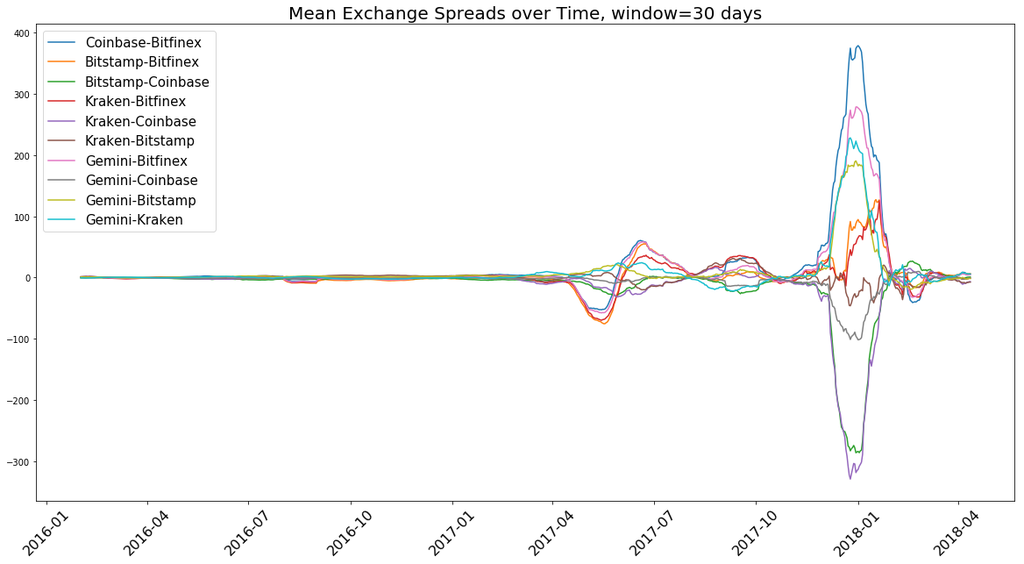

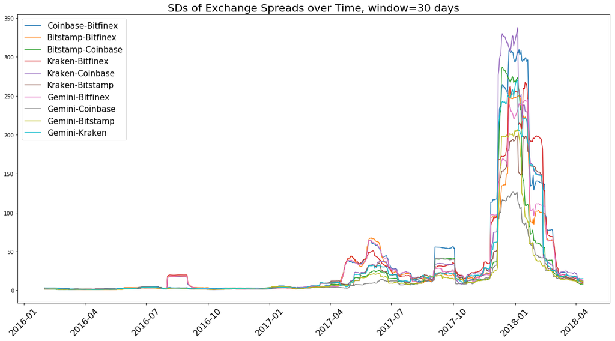

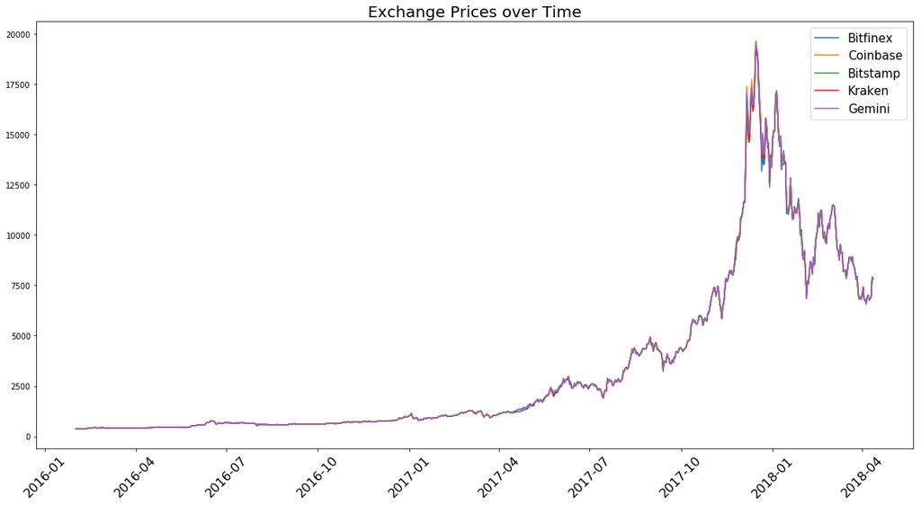

```python
# Params
window = 30  # num days to look over for each dist realization
dir_in = "../../data/in/"

# Read Data
dat = pd.read_csv(dir_in + "btc_cryptocompare_close.csv")

# Find Mean, SD for each Window and each Exchange Pair
# Size = (5 exchanges x 5 exchanges) x ~30 dates
df = dat.loc[:, dat.columns != 'date']  # no dates
exchanges = list(dat.columns[1:dat.shape[1]])
sprd_bin = np.zeros((len(exchanges), len(exchanges),
                     dat.shape[0]))
jexchanges = np.array(list(range(0, len(exchanges))))
for jexch in range(len(exchanges)):
    exchange = exchanges[jexch]
    diff = np.array(df.iloc[:, np.repeat(jexch, len(exchanges)-1)]) - \
           np.array(df.loc[:, df.columns != exchange])
    sprd_bin[jexch, jexchanges[jexchanges!=jexch]] = np.transpose(diff)

sprd_mean = np.zeros((len(exchanges), len(exchanges),
                      (dat.shape[0] - window)))
sprd_sd = np.zeros((len(exchanges), len(exchanges),
                      (dat.shape[0] - window)))
for jt in range(window, (dat.shape[0])):
    sub = sprd_bin[:, :, (jt-window):jt]
    sprd_mean[:, :, jt-window] = np.mean(sub, axis=2)
    sprd_sd[:, :, jt-window] = np.std(sub, axis=2)

# Plot Means and SDs over time
i = 0
while i < dat.shape[0]:
    dl = [int(x) for x in (dat.iloc[i, 0]).split('-')]
    dat.iloc[i, 0] = dt.datetime(dl[0], dl[1], dl[2])
    i += 1
x = list(dat.iloc[:, 0])
dates = x[window:len(x)]

plt.figure(figsize=(20, 10))
for x in range(1, len(exchanges)):
    for y in range(x):
        plt.plot(dates, sprd_mean[x, y, :], label=
        exchanges[x] + "-" + exchanges[y])

plt.xticks(size=16, rotation=45)
plt.legend(prop={'size': 15})
plt.title("Mean Exchange Spreads over Time, window="+str(window)+" days",
          size=20)
plt.show()

plt.figure(figsize=(20, 10))
for x in range(1, len(exchanges)):
    for y in range(x):
        plt.plot(dates, sprd_sd[x, y, :], label=
        exchanges[x] + "-" + exchanges[y])

plt.xticks(size=16, rotation=45)
plt.legend(prop={'size': 15})
plt.title("SDs of Exchange Spreads over Time, window="+str(window)+" days",
          size=20)
plt.show()

# Plot simple Time Series of each Exchange
plt.figure(figsize=(20, 10))
for x in range(0, len(exchanges)):
    plt.plot(dates, dat.iloc[window:dat.shape[0], x+1], label=
        exchanges[x])

plt.xticks(size=16, rotation=45)
plt.legend(prop={'size': 15})
plt.title("Exchange Prices over Time", size=20)
plt.show();
```

## Backtest Trades

```python
# Parameters
dir_in     = "../../data/in/"
acct_start = 1000  # dollars per exchange account
topmax     = 2     # the strongest n i,j *'s to trade
cush       = 0.15  # cushion to leave in acct bals
cost       = 0.002 # trading cost on total notional of trade
#window    = 30    # defined above
dev_thresh = 2     # num sd threshold

# Function Defs
def comp_sprds(prices):
    sprd = np.zeros((len(exchanges), len(exchanges)))
    for jexch in range(len(exchanges)):
        exchange = exchanges[jexch]
        diff = np.array(prices[np.repeat(jexch, len(exchanges)-1)]) - \
               np.array(prices[df.columns != exchange])
        sprd[jexch, jexchanges[jexchanges!=jexch]] = np.transpose(diff)
    return(sprd)

def most_common(lst):
    uniq = list(np.unique(lst))
    freq = [lst.count(x) for x in uniq]
    max_f = max(freq)
    return [uniq[i] for i in range(len(uniq)) if freq[i]==max_f]

# Backtest
exchanges = list(dat.columns[1:dat.shape[1]])
jexchanges = np.array(list(range(0, len(exchanges))))
acct_bals = np.zeros((df.shape[0]-window, df.shape[1]))  # dollars in exchanges (shape: time x num exchanges)
acct_bals[0, :] = acct_start
acct_poss = np.zeros((df.shape[0]-window, df.shape[1]))  # positions in each exchange (units)
ntrades = np.zeros((df.shape[0]-window, 1))

for jt in range(window, 73):
    ### Compute profit from last period and make sure account bals are positive ###
    if jt > window:
        price_chng = df.iloc[jt, :] - df.iloc[jt-1, :]
        acct_bals[jt-window, :] = acct_bals[jt-window-1, :] + acct_poss[jt-window-1, :] * price_chng
        #acct_bals[jt-window, :] = acct_bals[jt-window, :] * [acct_bals[jt-window, :] >= 0]
        acct_poss[jt-window, :] = acct_poss[jt-window, :] * [acct_bals[jt-window, :] >= 0]

    ### Find topmax highest deviations over threshold ###
    max_idx_list = []
    max_sd_devs = []
    sprds = comp_sprds(dat.iloc[jt,1:len(exchanges)+1])
    trail_means = sprd_mean[:, :, jt-window]
    trail_sd = sprd_sd[:, :, jt-window]
    numSD_devs = (sprds - trail_means) / (trail_sd + np.identity(len(exchanges)))
    numSD_devs = numSD_devs * (numSD_devs > dev_thresh)

    for jmax in range(topmax):
        bool_arr = np.multiply(np.matrix(numSD_devs == numSD_devs.max()), np.matrix(numSD_devs > dev_thresh))
        idx = np.where(bool_arr)
        if [x.size for x in idx] == [0, 0]:
            break  # No deviations past threshold
        max_idx_list.append(idx)
        max_sd_devs.append(numSD_devs[idx])
        numSD_devs[idx] = 0  # set to zero so next max doesn't pick it up
    if max_idx_list == []:
        continue  # no trades to be made

    ### Compute positions and dollars in each trade ###

    # This is where the trading logic is implemented. I've tried to
    # comment as much as possible to avoid confusion.

    temp_acct_bals = acct_bals  # we adjust acct bals while applying trading logic
        # and need to account when we use funds in each account. After the trading logic is
        # applied however the total val in account is = cash + positions so the temp vals will be
        # correct. This is why we create a temp version of them. The acct_bals variable in the
        # interim is an accounting object so we don't overdraw.

    shrt_idx = [int(x[0]) for x in max_idx_list]  # accounts to short
    long_idx = [int(x[1]) for x in max_idx_list]  # accounts to long
    max_sd_list = [int(x[0]) for x in max_sd_devs]  # max sd's in a list

    # Sort above based on highest sd
    shrt_idx = [x for _,x in sorted(zip(max_sd_list, shrt_idx), reverse=True)]
    long_idx = [x for _,x in sorted(zip(max_sd_list, long_idx), reverse=True)]
    max_sd_list = [x for _,x in sorted(zip(max_sd_list, max_sd_list), reverse=True)]


    numSD_devs = (sprds - trail_means) / (trail_sd + np.identity(len(exchanges)))
    numSD_devs = numSD_devs * (numSD_devs > dev_thresh)

    # Begin with most shorted accounts
    mst_comm_shrt = most_common(shrt_idx)  # most commonly shorted account(s)
    for jShrt in mst_comm_shrt:
        # all_accts lists all the accounts involved on either side of this trade
        long_accts = [long_idx[x] for x in range(len(shrt_idx)) if shrt_idx[x]==jShrt]
        all_accts = [jShrt] + long_accts
        bal_all_accts = acct_bals[jt-window, all_accts]
        min_accts = [all_accts[x] for x in range(len(bal_all_accts)) \
                     if bal_all_accts[x] == bal_all_accts.min()]  # which accounts have the min bal
        if jShrt in min_accts:  # if shorted account balance the lowest (or tied for it)
            # if so we split based on proportion of strength
            dllrs = acct_bals[jt-window, jShrt] * (1-cush)
            acct_bals[jt-window, jShrt] += dllrs
            print(str(dllrs) + "   " + str(jt))
            acct_poss[jt-window, jShrt] = acct_poss[jt-window, jShrt] \
                                            - float(df.iloc[jt, jShrt] / dllrs)  # Num coins to short

            for jLong in long_accts:
                jDev = [max_sd_list[x] for x in range(len(max_sd_list)) if long_idx[x] == jLong]
                sumDev = sum([max_sd_list[x] for x in range(len(max_sd_list)) if long_idx[x] in long_accts])
                dllrs = acct_bals[jt-window, jShrt] * (1-cush) * jDev[0] / sumDev  # proportional $
                acct_bals[jt-window, jLong] -= dllrs
                acct_poss[jt-window, jLong] = acct_poss[jt-window, jLong] \
                                                + float(df.iloc[jt, jLong] / dllrs)  # Num coins to long

        else:
            # if minimum bal is from one of the long accounts we split based on this requirement
            # e.g. min account trades all it can, with other leg mirroring, then other short account
            #  gets the rest
            for jLong in min_accts:
                dllrs = bal_all_accts.min() * (1-cush) # $ to go in min account
                acct_bals[jt-window, jLong] -= dllrs
                if acct_bals[jt-window, jLong] < 0:  # checks for acct bals below zero (only need to do for long)
                    acct_bals[jt-window, jLong] += dllrs
                    continue
                acct_bals[jt-window, jShrt] += dllrs
                print(str(dllrs) + "   " + str(jt))
                acct_poss[jt-window, jLong] = acct_poss[jt-window, jLong] \
                                                + float(df.iloc[jt, jLong] / dllrs)  # Num coins to long
                acct_poss[jt-window, jShrt] = acct_poss[jt-window, jShrt] \
                                                - float(df.iloc[jt, jShrt] / dllrs)  # Num coins to Short

                othr_long_accts = [long_idx[x] for x in range(len(shrt_idx)) if shrt_idx[x]==jShrt \
                                  and long_idx!=jLong]
                for jOthLong in othr_long_accts:
                    dllrs = np.min((acct_bals[jt-window, jOthLong], acct_bals[jt-window, jShrt])) \
                            * (1-cush)  # Max out minimum account (the rest)
                    acct_bals[jt-window, jOthLong] -= dllrs
                    acct_bals[jt-window, jShrt] += dllrs
                    acct_poss[jt-window, jOthLong] = acct_poss[jt-window, jOthLong] \
                                                        + float(df.iloc[jt, jOthLong] / dllrs)  # Num coins to long
                    acct_poss[jt-window, jShrt] = acct_poss[jt-window, jShrt] \
                                                    - float(df.iloc[jt, jShrt] / dllrs)  # Num coins to Short

        # remove accounts we already traded in
        temp_shrt_idx = shrt_idx
        shrt_idx = [x for x in shrt_idx if x != jShrt]
        long_idx = [long_idx[x] for x in range(len(long_idx)) if temp_shrt_idx[x] != jShrt]
        max_sd_list = [max_sd_list[x] for x in range(len(max_sd_list)) if temp_shrt_idx[x] != jShrt]
        del temp_shrt_idx

    # Move on to pairs that don't have duplicate shorts
    for jShrt in shrt_idx:
        jLong = [long_idx[x] for x in range(len(shrt_idx)) if shrt_idx[x] == jShrt][0]
        dllrs = np.min((acct_bals[jt-window, jLong], acct_bals[jt-window, jShrt])) \
                * (1-cush)  # Max out minimum account
        acct_bals[jt-window, jLong] -= dllrs
        acct_bals[jt-window, jShrt] += dllrs
        print(str(dllrs) + "   " + str(jt))
        acct_poss[jt-window, jLong] = acct_poss[jt-window, jLong] \
                                            + float(df.iloc[jt, jLong] / dllrs)  # Num coins to long
        acct_poss[jt-window, jShrt] = acct_poss[jt-window, jShrt] \
                                        - float(df.iloc[jt, jShrt] / dllrs)  # Num coins to Short

    # Readjust Account Balances
    acct_bals = temp_acct_bals
```

```
850.0   35
47.24681765765766   42
129.89625217098214   43
222.95050159572043   48
21.25540223217811   50
0.47824655022400775   50
850.0   54
32.13667500000009   62
0.7230751875000023   62
```

```python
acct_bals[10:20,:]
```

```
array([[  55.58449136, 1853.15104624, 1000.        ,  370.51397075,
        1000.        ],
       [  55.58449136, 1853.15104624, 1000.        ,  370.51397075,
        1000.        ],
       [ 102.83130902, 1853.15104624, 1000.        ,  283.10735808,
        1000.        ],
       [ 282.71537237, 1853.15104624, 1000.        ,    9.35145037,
        1000.        ],
       [ 262.29470776, 1853.15104624, 1000.        ,   25.00635557,
        1000.        ],
       [ 262.29470776, 1853.15104624, 1000.        ,   25.00635557,
        1000.        ],
       [ 262.29470776, 1853.15104624, 1000.        ,   25.00635557,
        1000.        ],
       [ 262.29470776, 1853.15104624, 1000.        ,   25.00635557,
        1000.        ],
       [ 485.24520936, 1853.15104624,  587.54157205,   25.00635557,
        1000.        ],
       [ 490.17305115, 1853.15104624,  584.83048767,   25.00635557,
        1000.        ]])
```

## Plot Account Balances

[figure not shown]

```python
plt.figure(figsize=(12,7))

for j in range(len(exchanges)):
    plt.subplot(2,3,j+1)
    plt.plot(acct_bals[:, j])
    plt.title(exchanges[j] + " account bal")
    plt.xlabel("Day"); plt.ylabel("USD")

plt.subplot(2,3,6)
plt.plot(np.sum(acct_bals, axis=1))
plt.title("Total (sum) account bal")
plt.xlabel("Day"); plt.ylabel("USD")

plt.tight_layout()
```

```
Total Portfolio RoR:-25.0
```

[figure not shown]

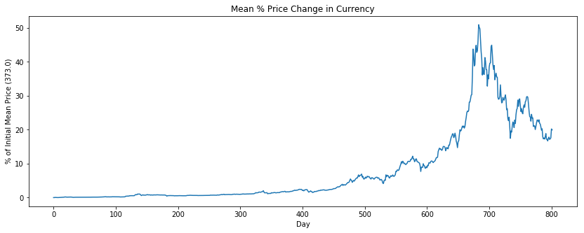

```python
print("Total Portfolio RoR:" + str((np.sum(acct_bals[acct_bals.shape[0]-1,:]) - acct_start*5) / acct_start*5))

plt.figure(figsize=(14,5))
plt.plot((np.sum(acct_bals, axis=1) - acct_start*5) / acct_start*5)
plt.title("RoR")
plt.xlabel("Day"); plt.ylabel("% of Starting Capital (5K)")
plt.show()

plt.figure(figsize=(14,5))
plt.plot([x for x in range(0, df.shape[0]-window)],
         (np.mean(df.iloc[window:df.shape[0], :], axis=1) - np.mean(df.iloc[window, :])) /
         np.mean(df.iloc[window,:]))
plt.title("Mean % Price Change in Currency")
strtpr = np.round(np.mean(df.iloc[window, :]))
plt.xlabel("Day"); plt.ylabel("% of Initial Mean Price " + "(" + str(strtpr) + ")")
plt.show()
```